# Experiment1 Analysis

```r
t.test(B1D050$responseR1, B1F050$responseR1, alternative = "two.sided", paired = FALSE) #no diff
```

```
##
##  Welch Two Sample t-test
##
## data:  B1D050$responseR1 and B1F050$responseR1
## t = -0.25491, df = 33.642, p-value = 0.8003
## alternative hypothesis: true difference in means is not equal to 0
## 95 percent confidence interval:
##  -1.994570  1.550126
## sample estimates:
## mean of x mean of y
##  4.388889  4.611111
```

```r
t.test(B1D100$responseR1, B1F100$responseR1, alternative = "two.sided", paired = FALSE) #diff, diamond higher than fossil
```

```
##
##  Welch Two Sample t-test
##
## data:  B1D100$responseR1 and B1F100$responseR1
## t = 3.4713, df = 35.291, p-value = 0.001386
## alternative hypothesis: true difference in means is not equal to 0
## 95 percent confidence interval:
##  0.9760812 3.7239188
## sample estimates:
## mean of x mean of y
##      4.80      2.45
```

```r
t.test(X1D000$responseR2, X1F000$responseR2, alternative = "two.sided", paired = FALSE) #diff, diamond higher than fossil
```

```
##
##  Welch Two Sample t-test
##
## data:  X1D000$responseR2 and X1F000$responseR2
## t = 2.8258, df = 121.37, p-value = 0.005517
## alternative hypothesis: true difference in means is not equal to 0
## 95 percent confidence interval:
##  0.3611967 2.0515017
## sample estimates:
## mean of x mean of y
##  5.555556  4.349206
```

```r
t.test(X1D050$responseR2, X1F050$responseR2, alternative = "two.sided", paired = FALSE) #no diff
```

```
##
##  Welch Two Sample t-test
##
## data:  X1D050$responseR2 and X1F050$responseR2
## t = 0.21946, df = 104.79, p-value = 0.8267
## alternative hypothesis: true difference in means is not equal to 0
## 95 percent confidence interval:
##  -0.7439974  0.9291825
## sample estimates:
## mean of x mean of y
##  5.092593  5.000000
```

```r
t.test(X1D100$responseR2, X1F100$responseR2, alternative = "two.sided", paired = FALSE) #no diff
```

```
##
##  Welch Two Sample t-test
##
## data:  X1D100$responseR2 and X1F100$responseR2
## t = 1.4739, df = 110.28, p-value = 0.1434
## alternative hypothesis: true difference in means is not equal to 0
## 95 percent confidence interval:
##  -0.2093809  1.4246815
## sample estimates:
## mean of x mean of y
##  5.066667  4.459016
```

```r
t.test(A3D000$responseR1, A3F000$responseR1, alternative = "two.sided", paired = FALSE) #diff, diamond higher than fossil
```

```
##
##  Welch Two Sample t-test
##
## data:  A3D000$responseR1 and A3F000$responseR1
## t = 3.6564, df = 27.126, p-value = 0.001085
## alternative hypothesis: true difference in means is not equal to 0
## 95 percent confidence interval:
##  1.463182 5.203485
## sample estimates:
## mean of x mean of y
##  6.933333  3.600000
```

```r
t.test(A3D050$responseR1, A3F050$responseR1, alternative = "two.sided", paired = FALSE) #diff, diamond higher than fossil
```

```
##
##  Welch Two Sample t-test
##
## data:  A3D050$responseR1 and A3F050$responseR1
## t = 2.0924, df = 39.988, p-value = 0.04279
## alternative hypothesis: true difference in means is not equal to 0
## 95 percent confidence interval:
##  0.06330923 3.65097649
## sample estimates:
## mean of x mean of y
##  6.142857  4.285714
```

```r
t.test(A3D100$responseR1, A3F100$responseR1, alternative = "two.sided", paired = FALSE) #no diff
```

```
##
##  Welch Two Sample t-test
##
## data:  A3D100$responseR1 and A3F100$responseR1
## t = 1.3945, df = 45.247, p-value = 0.17
## alternative hypothesis: true difference in means is not equal to 0
## 95 percent confidence interval:
##  -0.5366335  2.9533001
## sample estimates:
## mean of x mean of y
##  5.458333  4.250000
```

```r
t.test(B3D000$responseR1, B3F000$responseR1, alternative = "two.sided", paired = FALSE) #diff, fossil higher than diamond
```

```
##
##  Welch Two Sample t-test
##
## data:  B3D000$responseR1 and B3F000$responseR1
## t = -2.9523, df = 25.583, p-value = 0.006673
## alternative hypothesis: true difference in means is not equal to 0
## 95 percent confidence interval:
##  -4.5248130 -0.8085204
## sample estimates:
## mean of x mean of y
##  2.333333  5.000000
```

```r
t.test(B3D050$responseR1, B3F050$responseR1, alternative = "two.sided", paired = FALSE) #no diff
```

```
##
##  Welch Two Sample t-test
##
## data:  B3D050$responseR1 and B3F050$responseR1
## t = 0.26804, df = 39.822, p-value = 0.7901
## alternative hypothesis: true difference in means is not equal to 0
## 95 percent confidence interval:
##  -1.245952  1.626904
## sample estimates:
## mean of x mean of y
##  3.571429  3.380952
```

```r
t.test(B3D100$responseR1, B3F100$responseR1, alternative = "two.sided", paired = FALSE) #no diff
```

```
##
##  Welch Two Sample t-test
##
## data:  B3D100$responseR1 and B3F100$responseR1
## t = -1.2143, df = 45.448, p-value = 0.2309
## alternative hypothesis: true difference in means is not equal to 0
## 95 percent confidence interval:
##  -2.4367308  0.6033975
## sample estimates:
## mean of x mean of y
##  3.208333  4.125000
```

```r
t.test(X3D000$responseR2, X3F000$responseR2, alternative = "two.sided", paired = FALSE) #no diff
```

```
##
##  Welch Two Sample t-test
##
## data:  X3D000$responseR2 and X3F000$responseR2
## t = -1.2189, df = 57.956, p-value = 0.2278
## alternative hypothesis: true difference in means is not equal to 0
## 95 percent confidence interval:
##  -2.0256921  0.4923588
## sample estimates:
## mean of x mean of y
##  4.433333  5.200000
```

```r
t.test(X3D050$responseR2, X3F050$responseR2, alternative = "two.sided", paired = FALSE) #no diff (marginally? diamond higher than fossil)
```

```
##
##  Welch Two Sample t-test
##
## data:  X3D050$responseR2 and X3F050$responseR2
## t = 1.9373, df = 81.951, p-value = 0.05616
## alternative hypothesis: true difference in means is not equal to 0
## 95 percent confidence interval:
##  -0.02942729  2.21990348
## sample estimates:
## mean of x mean of y
##  5.476190  4.380952
```

```r
t.test(X3D100$responseR2, X3F100$responseR2, alternative = "two.sided", paired = FALSE) #no diff
```

```
##
##  Welch Two Sample t-test
##
## data:  X3D100$responseR2 and X3F100$responseR2
## t = 0.72158, df = 93.953, p-value = 0.4723
## alternative hypothesis: true difference in means is not equal to 0
## 95 percent confidence interval:
##  -0.6203735  1.3287068
## sample estimates:
## mean of x mean of y
##  4.916667  4.562500
```

I cannot get this to work. It seems as though X must be numeric? (it’s an int) But even forcing it to numeric does not work.

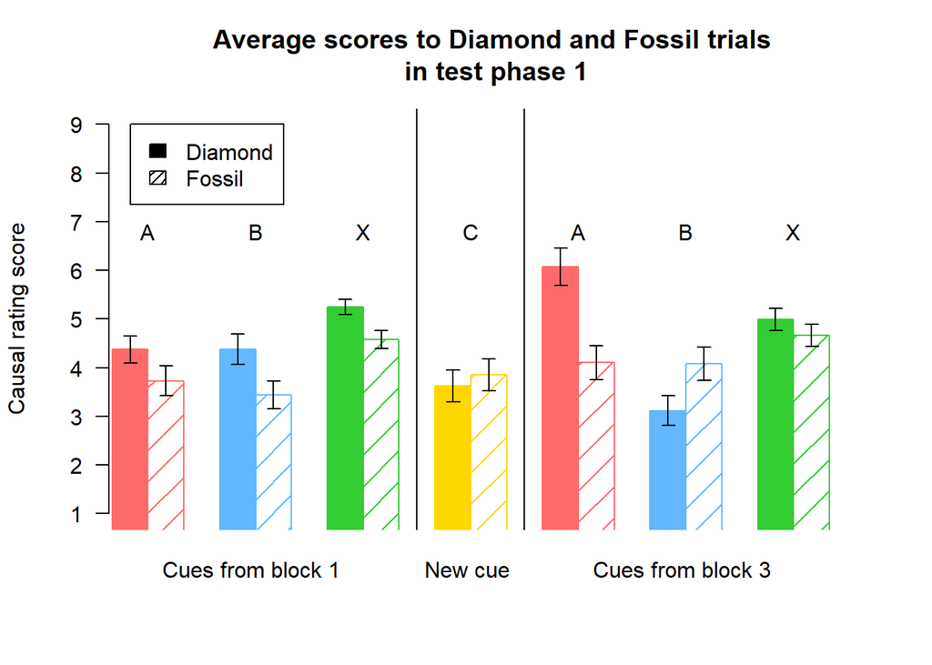

```r
SE_FD <- c(std.error(A1D$responseR1), std.error(A1F$responseR1),std.error(B1D$responseR1), std.error(B1F$responseR1), std.error(X1D$responseR2), std.error(X1F$responseR2), std.error(CD$responseR1), std.error(CF$responseR1), std.error(A3D$responseR1), std.error(A3F$responseR1),std.error(B3D$responseR1), std.error(B3F$responseR1), std.error(X3D$responseR2), std.error(X3F$responseR2))

par(mfrow = c(1,1))
par(las = 1)
emptyPlot(c(1,100), c(1,9), xaxt = "none", ymark= c(1,2,3,4,5,6,7,8,9), bty = 'n', main = "Average scores to Diamond and Fossil trials\n in test phase 1", xlab = "", ylab = "Causal rating score")
add_bars(x=c(0,5,15,20,30,35,45,50,60,65,75,80,90,95), y=c(avgA1D, avgA1F, avgA1D, avgB1F, avgX1D, avgX1F, avgCD, avgCF, avgA3D, avgA3F, avgB3D, avgB3F, avgX3D, avgX3F), width = 5, col = c("indianred1", "indianred1", "steelblue1", "steelblue1", "limegreen", "limegreen","gold", "gold", "indianred1", "indianred1", "steelblue1", "steelblue1", "limegreen", "limegreen"), density = c(200,6))

errorbars(x=c(0,5,15,20,30,35,45,50,60,65,75,80,90,95), y=c(avgA1D, avgA1F, avgA1D, avgB1F, avgX1D, avgX1F, avgCD, avgCF, avgA3D, avgA3F, avgB3D, avgB3F, avgX3D, avgX3F) , top = SE_FD , bottom = SE_FD, add = TRUE, length = .05)

abline(v=40, col="grey2", lty = 1)
abline(v=55, col="grey2", lty = 1)
#condition text
mtext("Cues from block 1", side = 1, at = 17, line = 1)
mtext("New cue", side = 1, at = 47, line = 1)
mtext("Cues from block 3", side = 1, at = 77, line = 1)
#letters
text(x=2.5, y = 6.8, labels = "A")
text(x=17.5, y = 6.8, labels = "B")
text(x=32.5, y = 6.8, labels = "X")
text(x=47.5, y = 6.8, labels = "C")
text(x=62.5, y = 6.8, labels = "A")
text(x=77.5, y = 6.8, labels = "B")
text(x=92.5, y = 6.8, labels = "X")
legend(x=0, y = 9, legend =c("Diamond", "Fossil"), density = c(200,20))
```

### Phase 2

In this phase participants saw the same stimuli as in Phase 1, but now in random order. We want to caclulate the average values of A, B and X to allergic and fever and see if they differ from those of Phase 1 (ideally they shouldnt).

```r
#Phase 2

#while the trials are in a different order this time around, Trial was a variable given to the _row_ in the table. So in order you will also see that it was "trials 9 then 4 then 8 for example.

#So we basically do the same as before but now I have to rename some things, because I still need stuff like X1F to compare with in a t.test.

testF2 <- testP2[which(testP2$Outcome == "Fossil.png"),]
testD2 <- testP2[which(testP2$Outcome == "Diamond.png"),]

#Now I want the average scores for A B and X for each of these outcomes, but also specifically A1, B1 etc. Therefore I will have to look at specific responses to trials. Therefore aggregate isn't very useful to use here.

#X
X1F2 <- testF2[which(testF2$Trial == 2 | testF2$Trial == 4 | testF2$Trial == 6),]
avgX1F2 <- mean(X1F2$responseR2, na.rm = T)
X1D2 <- testD2[which(testD2$Trial == 1 | testD2$Trial == 3 | testD2$Trial == 5),]
avgX1D2 <- mean(X1D2$responseR2, na.rm = T)
X3F2 <- testF2[which(testF2$Trial == 8 | testF2$Trial == 10),]
avgX3F2 <- mean(X3F2$responseR2, na.rm = T)
X3D2 <- testD2[which(testD2$Trial == 7 | testD2$Trial == 9),]
avgX3D2 <- mean(X3D2$responseR2, na.rm = T)

#A
A1F2 <- testF2[which(testF2$Trial == 2),]
avgA1F2 <- mean(A1F2$responseR1, na.rm = T)
A1D2 <- testD2[which(testD2$Trial == 1),]
avgA1D2 <- mean(A1D2$responseR1, na.rm = T)

A3F2 <- testF2[which(testF2$Trial == 8),]
avgA3F2 <- mean(A3F2$responseR1, na.rm = T)
A3D2 <- testD2[which(testD2$Trial == 7),]
avgA3D2 <- mean(A3D2$responseR1, na.rm = T)

#B
B1F2 <- testF2[which(testF2$Trial == 4),]
avgB1F2 <- mean(B1F2$responseR1, na.rm = T)
B1D2 <- testD2[which(testD2$Trial == 3),]
avgB1D2 <- mean(B1D2$responseR1, na.rm = T)

B3F2 <- testF2[which(testF2$Trial == 10),]
avgB3F2 <- mean(B3F2$responseR1, na.rm = T)
B3D2 <- testD2[which(testD2$Trial == 9),]
avgB3D2 <- mean(B3D2$responseR1, na.rm = T)

#C
CF2 <- testF2[which(testF2$Trial == 6),]
avgCF2 <- mean(CF2$responseR1, na.rm = T)
CD2 <- testD2[which(testD2$Trial == 5),]
avgCD2 <- mean(CD2$responseR1, na.rm = T)


Cue <- c("A1", "B1", "X1", "C", "A3", "B3", "X3")
Diamond2 <- c(avgA1D2, avgB1D2, avgX1D2, avgCD2, avgA3D2, avgB3D2, avgX3D2)
Fossil2 <- c(avgA1F2, avgB1F2, avgX1F2, avgCF2, avgA3F2, avgB3F2, avgX3F2)
Phase2 <- data.frame(Cue, Diamond2, Fossil2)
Phase2
```

```
##   Cue Diamond2  Fossil2
## 1  A1 4.416667 4.166667
## 2  B1 4.700000 4.116667
## 3  X1 5.422222 4.588889
## 4   C 3.550000 3.916667
## 5  A3 6.250000 3.366667
## 6  B3 3.083333 4.266667
## 7  X3 5.041667 4.391667
```

```r
Phase1_2 <- data.frame(Cue, Diamond, Fossil, Diamond2, Fossil2)
Phase1_2
```

```
##   Cue  Diamond   Fossil Diamond2  Fossil2
## 1  A1 4.372881 3.728814 4.416667 4.166667
## 2  B1 4.847458 3.440678 4.700000 4.116667
## 3  X1 5.248588 4.581921 5.422222 4.588889
## 4   C 3.627119 3.850000 3.550000 3.916667
## 5  A3 6.066667 4.100000 6.250000 3.366667
## 6  B3 3.116667 4.083333 3.083333 4.266667
## 7  X3 4.991667 4.658333 5.041667 4.391667
```

From first glace there don’t seem to be big differences, except maybe for A3’s score to fossil. Let’s see

```r
#All no diff, so there is no difference between the scores in Phase 2 and Phase 1 to Diamond
t.test(A1D$responseR1, A1D2$responseR1, alternative = "two.sided", paired = FALSE)
```

```
##
##  Welch Two Sample t-test
##
## data:  A1D$responseR1 and A1D2$responseR1
## t = -0.11408, df = 116.65, p-value = 0.9094
## alternative hypothesis: true difference in means is not equal to 0
## 95 percent confidence interval:
##  -0.8039240  0.7163534
## sample estimates:
## mean of x mean of y
##  4.372881  4.416667
```

```r
t.test(B1D$responseR1, B1D2$responseR1, alternative = "two.sided", paired = FALSE)
```

```
##
##  Welch Two Sample t-test
##
## data:  B1D$responseR1 and B1D2$responseR1
## t = 0.36063, df = 112.97, p-value = 0.7191
## alternative hypothesis: true difference in means is not equal to 0
## 95 percent confidence interval:
##  -0.6626383  0.9575535
## sample estimates:
## mean of x mean of y
##  4.847458  4.700000
```

```r
t.test(X1D$responseR2, X1D2$responseR2, alternative = "two.sided", paired = FALSE)
```

```
##
##  Welch Two Sample t-test
##
## data:  X1D$responseR2 and X1D2$responseR2
## t = -0.78956, df = 353.56, p-value = 0.4303
## alternative hypothesis: true difference in means is not equal to 0
## 95 percent confidence interval:
##  -0.6061390  0.2588697
## sample estimates:
## mean of x mean of y
##  5.248588  5.422222
```

```r
t.test(CD$responseR1, CD2$responseR1, alternative = "two.sided", paired = FALSE)
```

```
##
##  Welch Two Sample t-test
##
## data:  CD$responseR1 and CD2$responseR1
## t = 0.17374, df = 115.56, p-value = 0.8624
## alternative hypothesis: true difference in means is not equal to 0
## 95 percent confidence interval:
##  -0.8020658  0.9563031
## sample estimates:
## mean of x mean of y
##  3.627119  3.550000
```

```r
t.test(A3D$responseR1, A3D2$responseR1, alternative = "two.sided", paired = FALSE)
```

```
##
##  Welch Two Sample t-test
##
## data:  A3D$responseR1 and A3D2$responseR1
## t = -0.35006, df = 117.42, p-value = 0.7269
## alternative hypothesis: true difference in means is not equal to 0
## 95 percent confidence interval:
##  -1.2205071  0.8538405
## sample estimates:
## mean of x mean of y
##  6.066667  6.250000
```

```r
t.test(B3D$responseR1, B3D2$responseR1, alternative = "two.sided", paired = FALSE)
```

```
##
##  Welch Two Sample t-test
##
## data:  B3D$responseR1 and B3D2$responseR1
## t = 0.078842, df = 117.89, p-value = 0.9373
## alternative hypothesis: true difference in means is not equal to 0
## 95 percent confidence interval:
##  -0.8039055  0.8705722
## sample estimates:
## mean of x mean of y
##  3.116667  3.083333
```

```r
t.test(X3D$responseR2, X3D2$responseR2, alternative = "two.sided", paired = FALSE)
```

```
##
##  Welch Two Sample t-test
##
## data:  X3D$responseR2 and X3D2$responseR2
## t = -0.1605, df = 237.61, p-value = 0.8726
## alternative hypothesis: true difference in means is not equal to 0
## 95 percent confidence interval:
##  -0.6636905  0.5636905
## sample estimates:
## mean of x mean of y
##  4.991667  5.041667
```

```r
#all no diff too! So Phase 1 and 2 also don't differ in their scores to Fossil.
t.test(A1F$responseR1, A1F2$responseR1, alternative = "two.sided", paired = FALSE)
```

```
##
##  Welch Two Sample t-test
##
## data:  A1F$responseR1 and A1F2$responseR1
## t = -1.0471, df = 116.31, p-value = 0.2972
## alternative hypothesis: true difference in means is not equal to 0
## 95 percent confidence interval:
##  -1.2660621  0.3903559
## sample estimates:
## mean of x mean of y
##  3.728814  4.166667
```

```r
t.test(B1F$responseR1, B1F2$responseR1, alternative = "two.sided", paired = FALSE)
```

```
##
##  Welch Two Sample t-test
##
## data:  B1F$responseR1 and B1F2$responseR1
## t = -1.6495, df = 117, p-value = 0.1017
## alternative hypothesis: true difference in means is not equal to 0
## 95 percent confidence interval:
##  -1.4876061  0.1356287
## sample estimates:
## mean of x mean of y
##  3.440678  4.116667
```

```r
t.test(X1F$responseR2, X1F2$responseR2, alternative = "two.sided", paired = FALSE)
```

```
##
##  Welch Two Sample t-test
##
## data:  X1F$responseR2 and X1F2$responseR2
## t = -0.027459, df = 353.71, p-value = 0.9781
## alternative hypothesis: true difference in means is not equal to 0
## 95 percent confidence interval:
##  -0.506040  0.492104
## sample estimates:
## mean of x mean of y
##  4.581921  4.588889
```

```r
t.test(CF$responseR1, CF2$responseR1, alternative = "two.sided", paired = FALSE)
```

```
##
##  Welch Two Sample t-test
##
## data:  CF$responseR1 and CF2$responseR1
## t = -0.15186, df = 116.94, p-value = 0.8796
## alternative hypothesis: true difference in means is not equal to 0
## 95 percent confidence interval:
##  -0.9360887  0.8027554
## sample estimates:
## mean of x mean of y
##  3.850000  3.916667
```

```r
t.test(A3F$responseR1, A3F2$responseR1, alternative = "two.sided", paired = FALSE)
```

```
##
##  Welch Two Sample t-test
##
## data:  A3F$responseR1 and A3F2$responseR1
## t = 1.571, df = 116.76, p-value = 0.1189
## alternative hypothesis: true difference in means is not equal to 0
## 95 percent confidence interval:
##  -0.1911351  1.6578017
## sample estimates:
## mean of x mean of y
##  4.100000  3.366667
```

```r
t.test(B3F$responseR1, B3F2$responseR1, alternative = "two.sided", paired = FALSE)
```

```
##
##  Welch Two Sample t-test
##
## data:  B3F$responseR1 and B3F2$responseR1
## t = -0.36233, df = 116.87, p-value = 0.7178
## alternative hypothesis: true difference in means is not equal to 0
## 95 percent confidence interval:
##  -1.1854235  0.8187568
## sample estimates:
## mean of x mean of y
##  4.083333  4.266667
```

```r
t.test(X3F$responseR2, X3F2$responseR2, alternative = "two.sided", paired = FALSE)
```

```
##
##  Welch Two Sample t-test
##
## data:  X3F$responseR2 and X3F2$responseR2
## t = 0.82071, df = 237.99, p-value = 0.4126
## alternative hypothesis: true difference in means is not equal to 0
## 95 percent confidence interval:
##  -0.3734200  0.9067534
## sample estimates:
## mean of x mean of y
##  4.658333  4.391667
```